# Travaux Pratiques

# Exercise 1 : Vecteur dans R

## Question 1

### 1.a)

```r
x # renvoie le vecteur precedemment crée
```

```
## [1] 3 1 7
```

### 1.b)

```r
x[2] # la valeur à la deuxième position
```

```
## [1] 1
```

### 1.c)

```r
length(x)# la taille du vecteur x
```

```
## [1] 3
```

### 1.d)

```r
sum(x)# la somme des valeurs de x
```

```
## [1] 11
```

### 1.e)

```r
x+y # la somme des vecteurs x et y
```

```
## [1] 4 2 8
```

### 1.f)

```r
x*y # la multiplication du vecteur x par le vecteur y
```

```
## [1] 3 1 7
```

### 1.g)

```r
sort(x) # trie les valeurs du vecteur par ordre croissant
```

```
## [1] 1 3 7
```

### 1.h)

```r
min(x)# le min de x
```

```
## [1] 1
```

### 1.i)

```r
which.min(x)# la position du min dans le vecteur
```

```
## [1] 2
```

### 1.j)

```r
z<-x # affecte x à z
z
```

```
## [1] 3 1 7
```

## Question 2

```r
sort(x,decreasing = TRUE)
```

```
## [1] 7 3 1
```

## Question 3

### 3.a)

```r
u==8 # un booleen : true si la valeur équivaut à 8 et false sinon
```

```
##  [1] FALSE FALSE FALSE FALSE FALSE FALSE FALSE FALSE FALSE FALSE  TRUE  TRUE
## [13]  TRUE  TRUE  TRUE  TRUE  TRUE  TRUE  TRUE  TRUE  TRUE  TRUE  TRUE  TRUE
## [25]  TRUE  TRUE  TRUE  TRUE  TRUE  TRUE FALSE FALSE FALSE FALSE FALSE
```

### 3.b)

```r
u<=8 # un booleen : true si la valeur de u <= 8 et false sinon
```

```
##  [1]  TRUE  TRUE  TRUE  TRUE  TRUE  TRUE  TRUE  TRUE  TRUE  TRUE  TRUE  TRUE
## [13]  TRUE  TRUE  TRUE  TRUE  TRUE  TRUE  TRUE  TRUE  TRUE  TRUE  TRUE  TRUE
## [25]  TRUE  TRUE  TRUE  TRUE  TRUE  TRUE FALSE FALSE FALSE FALSE FALSE
```

### 3.c)

```r
(which(u %in% c(2,9)))# la position des valeurs 2 et 9 de u
```

```
##  [1]  1  2  3  4  5  6  7  8  9 10 31 32 33 34 35
```

### 3.d)

```r
which((u==2)|(u==9)) #la position des valeurs 2 ou 9 de u
```

```
##  [1]  1  2  3  4  5  6  7  8  9 10 31 32 33 34 35
```

### 3.e)

```r
which((u==2)&(u==9))# la position des valeurs qui sont à la fois 2 et 9
```

```
## integer(0)
```

## Question 4

```r
length(which(u %in% c(8,9)))
```

```
## [1] 25
```

## Question 5

### 5.a)

```r
mode(groupe)# le type de groupe
```

```
## [1] "character"
```

### 5.b)

```r
mode(u)# renvoie le type de u
```

```
## [1] "numeric"
```

### 5.c)

```r
mode(u==5) # le type de u==5
```

```
## [1] "logical"
```

## Question 6

### 6.a)

```r
ls() # liste les trucs existants dans le global environnement de R
```

```
## [1] "groupe" "u"      "x"      "y"      "z"
```

### 6.b)

```r
rm(list=ls())# supprime le stockage de global environnement
```

### 6.c)

```r
ls()
```

```
## character(0)
```

# Exercice 2 : Manipulation de donnees avec R

## Question 1

**Le jeu de données mesure la qualité de l’air à new York. Il comporte des variables Ozone, Solar.r, Wind, temperature, month et le jour du mois**

## Question 2

### 2.a)

```r
head(airquality)# l'en-tête du jeu de données airquality
```

```
##   Ozone Solar.R Wind Temp Month Day
## 1    41     190  7.4   67     5   1
## 2    36     118  8.0   72     5   2
## 3    12     149 12.6   74     5   3
## 4    18     313 11.5   62     5   4
## 5    NA      NA 14.3   56     5   5
## 6    28      NA 14.9   66     5   6
```

### 2.b)

```r
str(airquality)# le type de chaque variable avec un début de descriptif du contenu
```

```
## 'data.frame':    153 obs. of  6 variables:
##  $ Ozone  : int  41 36 12 18 NA 28 23 19 8 NA ...
##  $ Solar.R: int  190 118 149 313 NA NA 299 99 19 194 ...
##  $ Wind   : num  7.4 8 12.6 11.5 14.3 14.9 8.6 13.8 20.1 8.6 ...
##  $ Temp   : int  67 72 74 62 56 66 65 59 61 69 ...
##  $ Month  : int  5 5 5 5 5 5 5 5 5 5 ...
##  $ Day    : int  1 2 3 4 5 6 7 8 9 10 ...
```

### 2.c)

```r
summary(airquality)# un résumé sur le dataframe
```

```
##      Ozone           Solar.R           Wind             Temp
##  Min.   :  1.00   Min.   :  7.0   Min.   : 1.700   Min.   :56.00
##  1st Qu.: 18.00   1st Qu.:115.8   1st Qu.: 7.400   1st Qu.:72.00
##  Median : 31.50   Median :205.0   Median : 9.700   Median :79.00
##  Mean   : 42.13   Mean   :185.9   Mean   : 9.958   Mean   :77.88
##  3rd Qu.: 63.25   3rd Qu.:258.8   3rd Qu.:11.500   3rd Qu.:85.00
##  Max.   :168.00   Max.   :334.0   Max.   :20.700   Max.   :97.00
##  NA's   :37       NA's   :7
##      Month            Day
##  Min.   :5.000   Min.   : 1.0
##  1st Qu.:6.000   1st Qu.: 8.0
##  Median :7.000   Median :16.0
##  Mean   :6.993   Mean   :15.8
##  3rd Qu.:8.000   3rd Qu.:23.0
##  Max.   :9.000   Max.   :31.0
##
```

### 2.d)

```r
colnames(airquality)#le nom des colonnes
```

```
## [1] "Ozone"   "Solar.R" "Wind"    "Temp"    "Month"   "Day"
```

### 2.e)

```r
dim(airquality)# la dimension: le nombre de lignes et de colonnes de airquality
```

```
## [1] 153   6
```

## Question 3

**attach(dataframe) permet d’appeler les colonnes avec leur simple nom. Sinon il faut necessairement écrire dataframe$colonne**

## Question 4

### 4.a)

```r
sum(is.na(airquality))# le nombre total de NA existant dans le dataframe
```

```
## [1] 44
```

### 4.b)

```r
dataTemp = c()
dataTemp <-na.omit(airquality)#  supprime les NA existant dans airquality et creer un dataframe dataTemp qui stocke que les valeurs existantes
```

### 4.c)

```r
sum(is.na(dataTemp))# On voit bien qu'il n'y a plus de NA
```

```
## [1] 0
```

## Question 5

### 5.a)

```r
attach(dataTemp)
mode(Ozone) # Ozone est de type numeric
```

```
## [1] "numeric"
```

### 5.b)

```r
mean(Ozone)
```

```
## [1] 42.0991
```

```r
median(Ozone)
```

```
## [1] 31
```

```r
var(Ozone)
```

```
## [1] 1107.29
```

```r
sd(Ozone)
```

```
## [1] 33.27597
```

### 5.c)

**La valeur moyenne prise par Ozone est de 42, la moitié des observations ont pour valeur inférieure à 31; et les observations sont un peu dispersées**

### 5.d)

```r
quantile(Ozone)
```

```
##   0%  25%  50%  75% 100%
##    1   18   31   62  168
```

```r
IQR(Ozone) #la taille de l'intervalle interquartile est 44
```

```
## [1] 44
```

### 5.f) indice de l’observation ayant la plus grande valeur

```r
which.max(Ozone)# indice de l'observation ayant la plus grande valeur d'ozone
```

```
## [1] 77
```

## Question 6

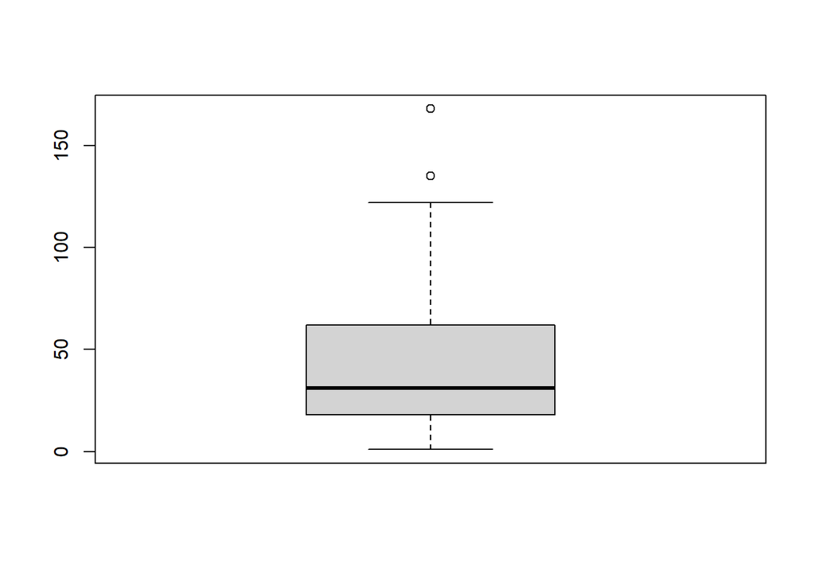

```
## [1] 135 168
```

```r
boxplot(Ozone)$out
```

## Question 7

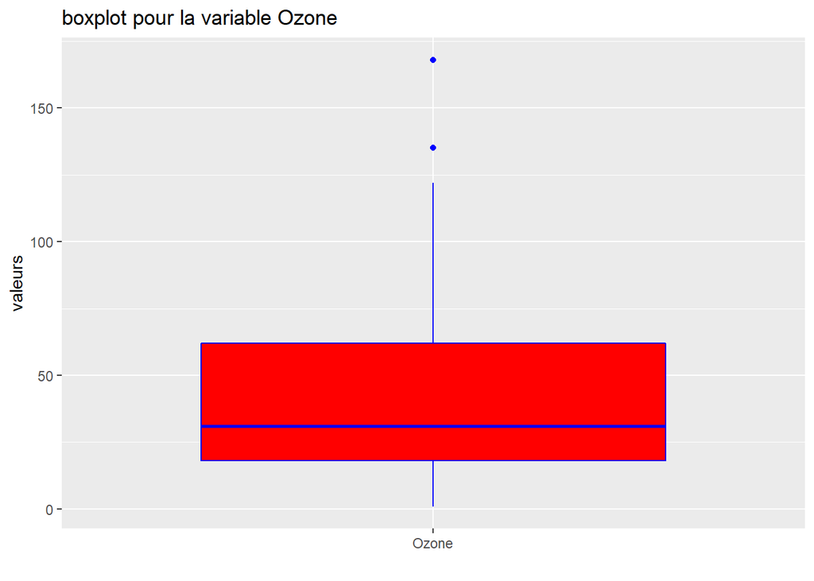

```r
library(ggplot2)
require(ggplot2)
fig <- ggplot(data.frame(Ozone)) + aes(x="Ozone",y = Ozone)+
  geom_boxplot(color = "blue", fill = "red")+
  labs(title="boxplot pour la variable Ozone", x ="", y= "valeurs")
fig
```

## Question 8

### 8.a)

```r
mode(Month)
```

```
## [1] "numeric"
```

**Month est de type numéric**

### 8.b)

```r
table(Month)
```

```
## Month
##  5  6  7  8  9
## 24  9 26 23 29
```

```r
prop.table(table(Month))
```

```
## Month
##          5          6          7          8          9
## 0.21621622 0.08108108 0.23423423 0.20720721 0.26126126
```

Au mois de juin le pourcentage est de 8.10, celui de juillet est 23.42

### 8.c)

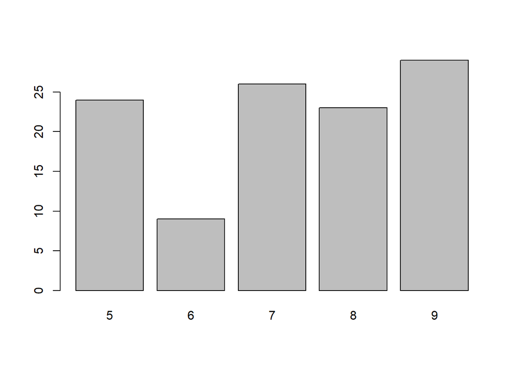

```r
barplot(table(Month))
```

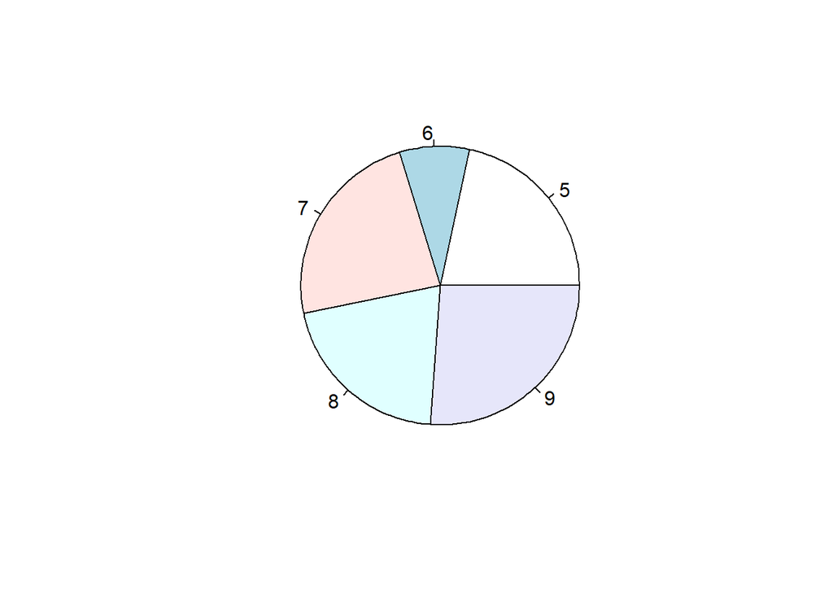

```r
pie(table(Month))
```

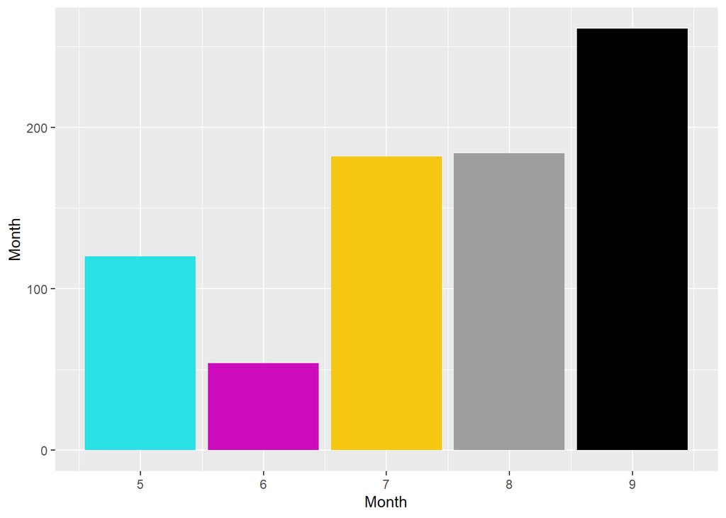

```r
figure <- ggplot(data.frame(Month)) + aes(x = Month, y = Month) +
  geom_bar(stat="identity", fill=Month)
figure
```

### 8.d)

```r
vecteur <- as.factor(Month)
d <- factor(vecteur, levels = 5:9, labels = c("mai","juin","juilet","aôut","septembre"))
```

## Question 9

### 9.a)

```r
tapply(Ozone,Month,mean)
```

```
##        5        6        7        8        9
## 24.12500 29.44444 59.11538 60.00000 31.44828
```

```r
tapply(Ozone,Month,sd)
```

```
##        5        6        7        8        9
## 22.88594 18.20790 31.63584 41.76776 24.14182
```

### 9.b)

```r
Month == 7 & Ozone >50
```

```
##   [1] FALSE FALSE FALSE FALSE FALSE FALSE FALSE FALSE FALSE FALSE FALSE FALSE
##  [13] FALSE FALSE FALSE FALSE FALSE FALSE FALSE FALSE FALSE FALSE FALSE FALSE
##  [25] FALSE FALSE FALSE FALSE FALSE FALSE FALSE FALSE FALSE  TRUE FALSE FALSE
##  [37]  TRUE FALSE  TRUE  TRUE  TRUE  TRUE FALSE FALSE FALSE FALSE FALSE  TRUE
##  [49]  TRUE  TRUE FALSE  TRUE  TRUE FALSE  TRUE  TRUE FALSE  TRUE  TRUE FALSE
##  [61] FALSE FALSE FALSE FALSE FALSE FALSE FALSE FALSE FALSE FALSE FALSE FALSE
##  [73] FALSE FALSE FALSE FALSE FALSE FALSE FALSE FALSE FALSE FALSE FALSE FALSE
##  [85] FALSE FALSE FALSE FALSE FALSE FALSE FALSE FALSE FALSE FALSE FALSE FALSE
##  [97] FALSE FALSE FALSE FALSE FALSE FALSE FALSE FALSE FALSE FALSE FALSE FALSE
## [109] FALSE FALSE FALSE
```

```r
prop.table(table(Month== 7 & Ozone >50))
```

```
##
##     FALSE      TRUE
## 0.8648649 0.1351351
```

```r
Month == 9 & Ozone >50
```

```
##   [1] FALSE FALSE FALSE FALSE FALSE FALSE FALSE FALSE FALSE FALSE FALSE FALSE
##  [13] FALSE FALSE FALSE FALSE FALSE FALSE FALSE FALSE FALSE FALSE FALSE FALSE
##  [25] FALSE FALSE FALSE FALSE FALSE FALSE FALSE FALSE FALSE FALSE FALSE FALSE
##  [37] FALSE FALSE FALSE FALSE FALSE FALSE FALSE FALSE FALSE FALSE FALSE FALSE
##  [49] FALSE FALSE FALSE FALSE FALSE FALSE FALSE FALSE FALSE FALSE FALSE FALSE
##  [61] FALSE FALSE FALSE FALSE FALSE FALSE FALSE FALSE FALSE FALSE FALSE FALSE
##  [73] FALSE FALSE FALSE FALSE FALSE FALSE FALSE FALSE FALSE FALSE  TRUE  TRUE
##  [85]  TRUE  TRUE FALSE FALSE FALSE FALSE FALSE FALSE FALSE FALSE FALSE FALSE
##  [97] FALSE FALSE FALSE FALSE FALSE FALSE FALSE FALSE FALSE FALSE FALSE FALSE
## [109] FALSE FALSE FALSE
```

```r
prop.table(table(Month== 9 & Ozone >50))
```

```
##
##      FALSE       TRUE
## 0.96396396 0.03603604
```

### 9.c)

[figure not shown]

```r
df <-data.frame(Ozone = Ozone, Month = as.factor(Month))
fig <- ggplot(df) + aes(x=Month, y= "Ozone",fill = Month) + geom_boxplot() +
  labs(x ="Month", y = "Ozone",fill= "Mois")
fig
```

### 9.d)

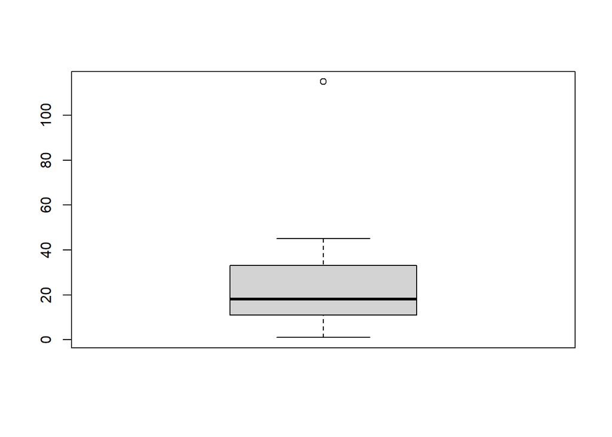

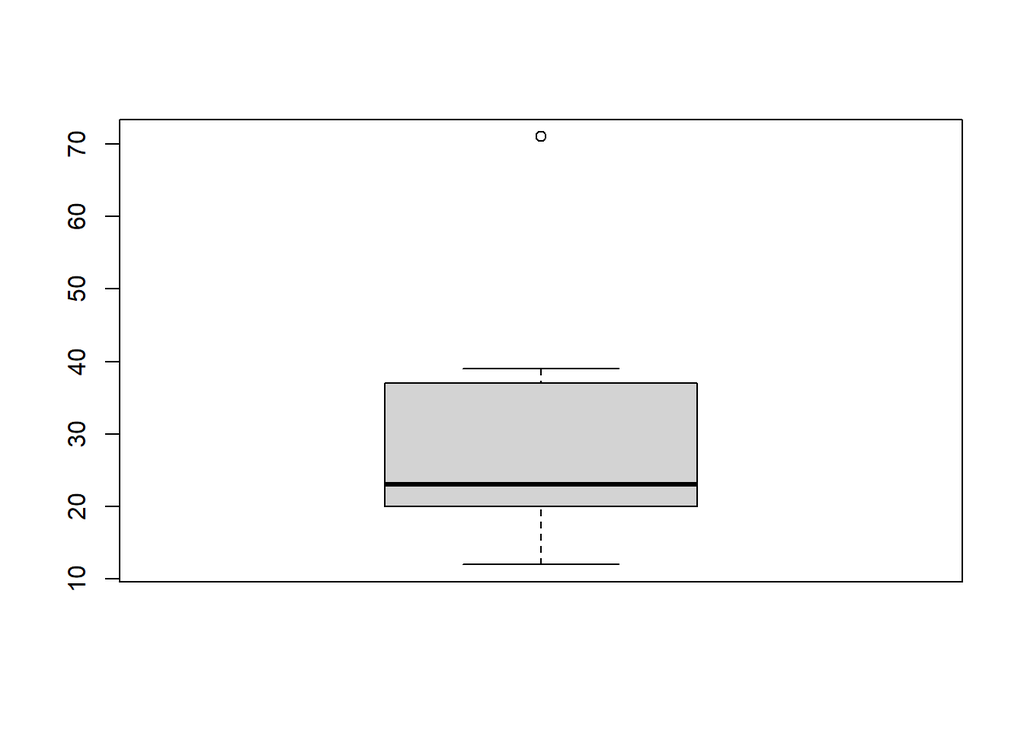

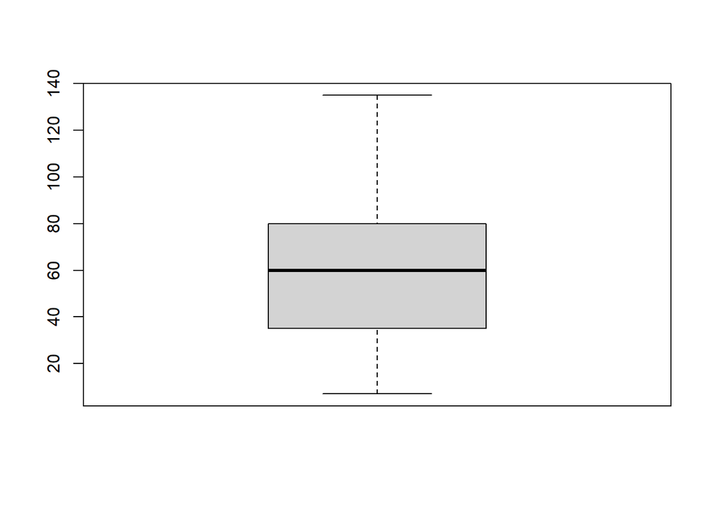

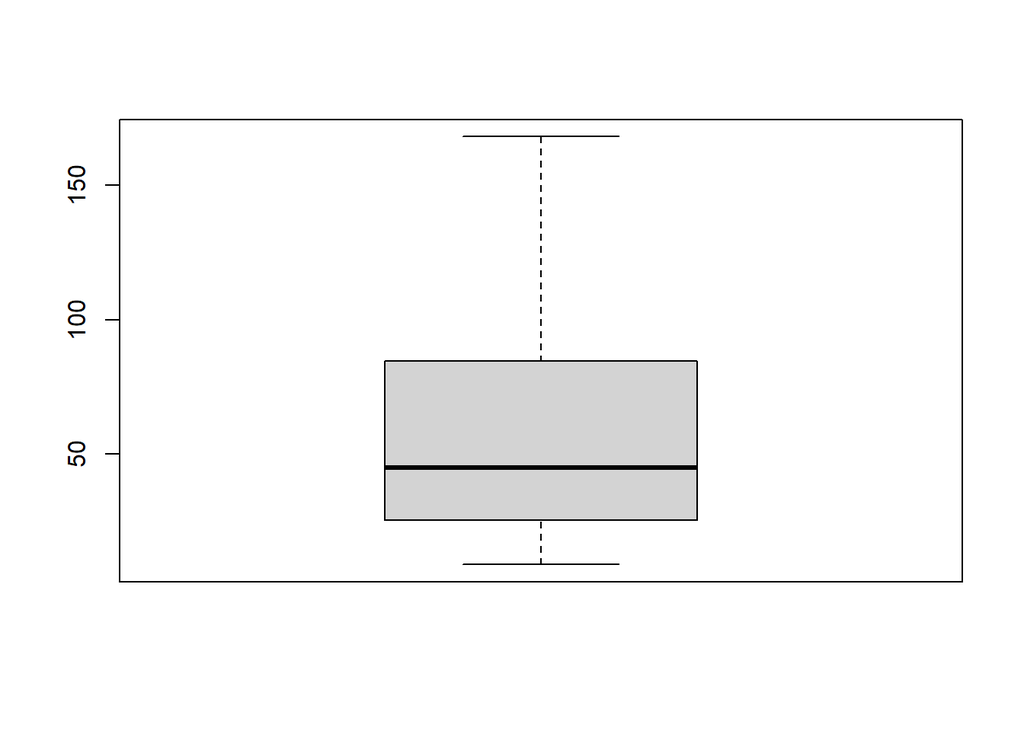

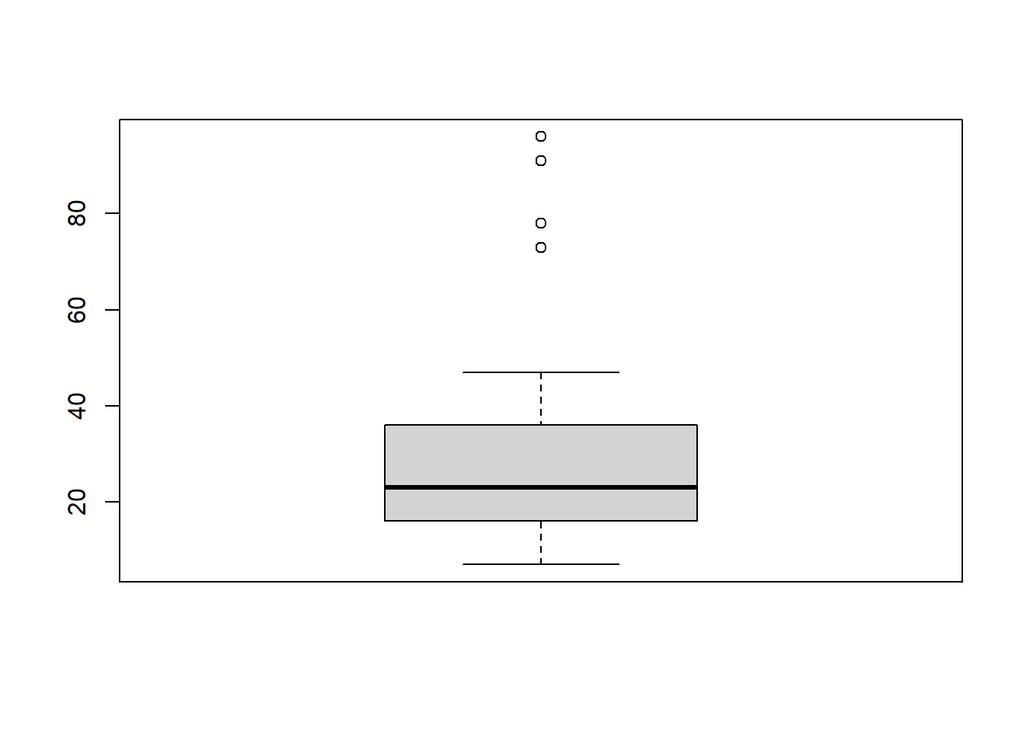

```
## 5 6 7 8 9
## 1 1 0 0 4
```

```r
tapply(X =df$Ozone,INDEX = df$Month,function(x)length(boxplot(x)$out))
```

## Question 10

### 10.a)

```r
OzoneCent <- Ozone-mean(Ozone)
OzoneRed <- Ozone <- Ozone/ sd(Ozone)
mean(OzoneCent)
```

```
## [1] -7.643723e-16
```

```r
var(OzoneRed)
```

```
## [1] 1
```

```r
scale(Ozone)# pour centrer réduire simultanément on utilise scale
```

[output not shown]

### 10.b)

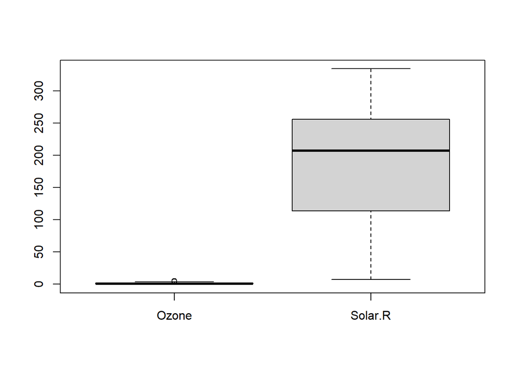

```r
tab <- data.frame(Ozone=Ozone,Solar.R = Solar.R)
boxplot(tab)
```

```r
tabCR = data.frame(apply(tab,MARGIN = 2, scale))
```

**boxplot de tab renvoie le boxplot de ozone et solar.r avec des valeurs non centrées reduites**

### 10.c)

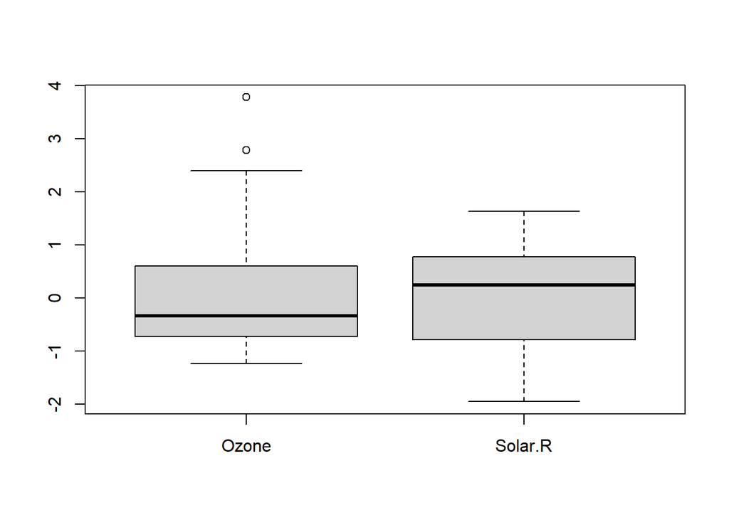

```r
boxplot(tabCR)
```

### 10.d)

```r
library(reshape)
df <- melt(data.frame(Ozone= tabCR$Ozone,Solar.R = tabCR$Solar.R))
```

```
## Using  as id variables
```

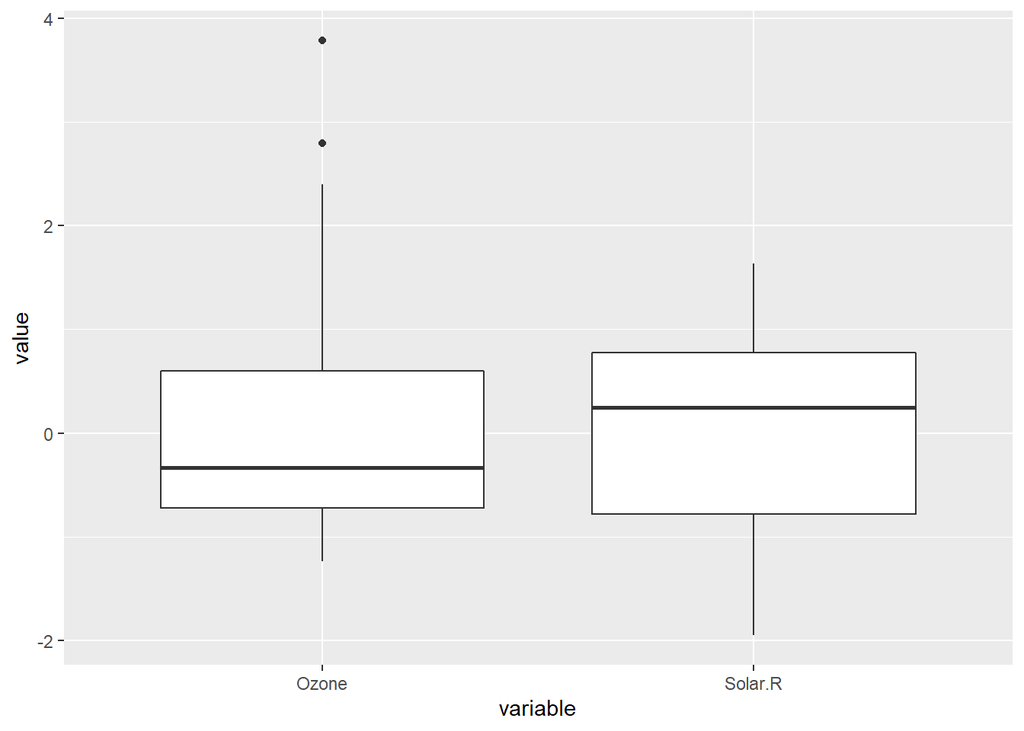

```r
fig <-ggplot(df) + geom_boxplot(aes(x=variable, y=value))
fig
```

## Question 11

```r
write.csv(dataTemp,file ="airquality.csv,quote = FALSE")
```

# Exercice3 : Ecriture de fonctions avec R

```r
carre <- function(x){
  out <-x*x
  return(out)}
carre(5)
```

```
## [1] 25
```

## Question 1

```r
centreReduit <- function(x){
  out <- scale(x)
  return(out)}
```

```r
centreReduit(airquality)
```